# INN Hotels Project

## Model performance evaluation

#### Model Performance Improvement

- Let's see if the recall score can be improved further, by changing the model threshold using AUC-ROC Curve.

#### Optimal threshold using AUC-ROC curve

```python
# Optimal threshold as per AUC-ROC curve
# The optimal cut off would be where tpr is high and fpr is low
fpr, tpr, thresholds = roc_curve(y_train, lg1.predict(X_train1))

optimal_idx = np.argmax(tpr - fpr)
optimal_threshold_auc_roc = thresholds[optimal_idx]
print(optimal_threshold_auc_roc)
```

```
0.3700522558707788
```

```
None
```

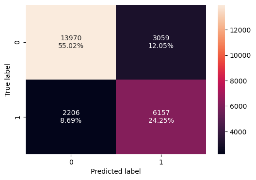

```python
# creating confusion matrix
conf_matrix_result = confusion_matrix_statsmodels(
    lg1, X_train1, y_train, optimal_threshold_auc_roc
)

print(conf_matrix_result)
# This code will print the confusion matrix for the training data using the optimal threshold derived from the AUC-ROC curve
```

```python
# checking model performance for this model
log_reg_model_train_perf_threshold_auc_roc = (
    model_performance_classification_statsmodels(
        lg1, X_train1, y_train, threshold=optimal_threshold_auc_roc
    )
)
print("Training performance:")
log_reg_model_train_perf_threshold_auc_roc
```

```
Training performance:
```

|  | Accuracy | Recall | Precision | F1 |
| --- | --- | --- | --- | --- |
| 0 | 0.79265 | 0.73622 | 0.66808 | 0.70049 |

#### Let's use Precision-Recall curve and see if we can find a better threshold

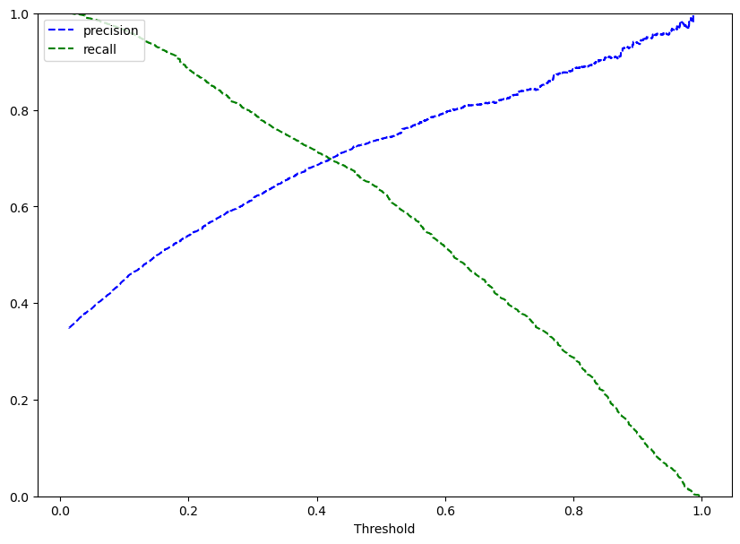

```python
y_scores = lg1.predict(X_train1)
prec, rec, tre = precision_recall_curve(
    y_train,
    y_scores,
)


def plot_prec_recall_vs_tresh(precisions, recalls, thresholds):
    plt.plot(thresholds, precisions[:-1], "b--", label="precision")
    plt.plot(thresholds, recalls[:-1], "g--", label="recall")
    plt.xlabel("Threshold")
    plt.legend(loc="upper left")
    plt.ylim([0, 1])


plt.figure(figsize=(10, 7))
plot_prec_recall_vs_tresh(prec, rec, tre)
plt.show()
```

```python
# setting the threshold
optimal_threshold_curve = 0.42
```

#### Checking model performance on training set

```
None
```

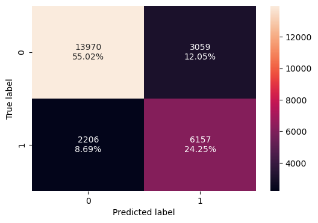

```python
# creating confusion matrix
confusion_matrix_result = confusion_matrix_statsmodels(
    lg1, X_train1, y_train, optimal_threshold_auc_roc
)

print(confusion_matrix_result)
```

```python
log_reg_model_train_perf_threshold_curve = model_performance_classification_statsmodels(
    lg1, X_train1, y_train, threshold=optimal_threshold_curve
)
print("Training performance:")
log_reg_model_train_perf_threshold_curve
```

```
Training performance:
```

|  | Accuracy | Recall | Precision | F1 |
| --- | --- | --- | --- | --- |
| 0 | 0.80132 | 0.69939 | 0.69797 | 0.69868 |

#### Let's check the performance on the test set

**Using model with default threshold**

```
None
```

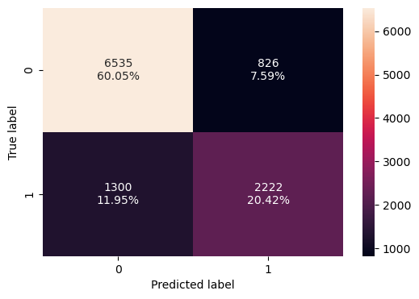

```python
confusion_matrix_result = confusion_matrix_statsmodels(lg1, X_test1, y_test)
print(confusion_matrix_result)
```

```python
log_reg_model_test_perf = model_performance_classification_statsmodels(
    lg1, X_test1, y_test
)
print("Test performance:")
log_reg_model_test_perf
```

```
Test performance:
```

|  | Accuracy | Recall | Precision | F1 |
| --- | --- | --- | --- | --- |
| 0 | 0.80465 | 0.63089 | 0.72900 | 0.67641 |

- ROC curve on test set

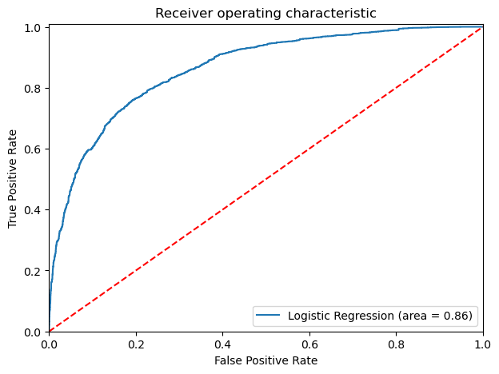

```python
logit_roc_auc_train = roc_auc_score(y_test, lg1.predict(X_test1))
fpr, tpr, thresholds = roc_curve(y_test, lg1.predict(X_test1))
plt.figure(figsize=(7, 5))
plt.plot(fpr, tpr, label="Logistic Regression (area = %0.2f)" % logit_roc_auc_train)
plt.plot([0, 1], [0, 1], "r--")
plt.xlim([0.0, 1.0])
plt.ylim([0.0, 1.01])
plt.xlabel("False Positive Rate")
plt.ylabel("True Positive Rate")
plt.title("Receiver operating characteristic")
plt.legend(loc="lower right")
plt.show()
```

**Using model with threshold=0.37**

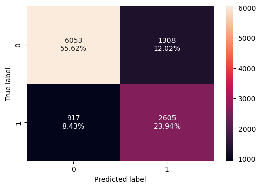

```python
# creating confusion matrix
confusion_matrix_statsmodels(lg1, X_test1, y_test, threshold=optimal_threshold_auc_roc)
```

```python
# checking model performance for this model
log_reg_model_test_perf_threshold_auc_roc = (
    model_performance_classification_statsmodels(
        lg1, X_test1, y_test, threshold=optimal_threshold_auc_roc
    )
)
print("Test performance:")
log_reg_model_test_perf_threshold_auc_roc
```

```
Test performance:
```

|  | Accuracy | Recall | Precision | F1 |
| --- | --- | --- | --- | --- |
| 0 | 0.79555 | 0.73964 | 0.66573 | 0.70074 |

**Using model with threshold = 0.42**

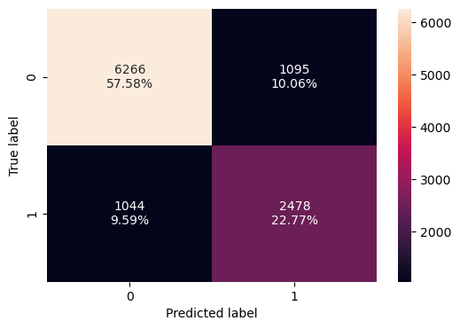

```python
# creating confusion matrix
confusion_matrix_statsmodels(lg1, X_test1, y_test, threshold=optimal_threshold_curve)
```

```python
log_reg_model_test_perf_threshold_curve = model_performance_classification_statsmodels(
    lg1, X_test1, y_test, threshold=optimal_threshold_curve
)
print("Test performance:")
log_reg_model_test_perf_threshold_curve
```

```
Test performance:
```

|  | Accuracy | Recall | Precision | F1 |
| --- | --- | --- | --- | --- |
| 0 | 0.80345 | 0.70358 | 0.69353 | 0.69852 |

## Final Model Summary

```python
# training performance comparison

models_train_comp_df = pd.concat(
    [
        log_reg_model_train_perf.T,
        log_reg_model_train_perf_threshold_auc_roc.T,
        log_reg_model_train_perf_threshold_curve.T,
    ],
    axis=1,
)
models_train_comp_df.columns = [
    "Logistic Regression-default Threshold",
    "Logistic Regression-0.37 Threshold",
    "Logistic Regression-0.42 Threshold",
]

print("Training performance comparison:")
models_train_comp_df
```

```
Training performance comparison:
```

|  | Logistic Regression-default Threshold | Logistic Regression-0.37 Threshold | Logistic Regression-0.42 Threshold |
| --- | --- | --- | --- |
| Accuracy | 0.80545 | 0.79265 | 0.80132 |
| Recall | 0.63267 | 0.73622 | 0.69939 |
| Precision | 0.73907 | 0.66808 | 0.69797 |
| F1 | 0.68174 | 0.70049 | 0.69868 |

```python
# training performance comparison

models_test_comp_df = pd.concat(
    [
        log_reg_model_test_perf.T,
        log_reg_model_test_perf_threshold_auc_roc.T,
        log_reg_model_test_perf_threshold_curve.T,
    ],
    axis=1,
)
models_test_comp_df.columns = [
    "Logistic Regression-default Threshold",
    "Logistic Regression-0.37 Threshold",
    "Logistic Regression-0.42 Threshold",
]

print("Test performance comparison:")
models_test_comp_df
```

```
Test performance comparison:
```

|  | Logistic Regression-default Threshold | Logistic Regression-0.37 Threshold | Logistic Regression-0.42 Threshold |
| --- | --- | --- | --- |
| Accuracy | 0.80465 | 0.79555 | 0.80345 |
| Recall | 0.63089 | 0.73964 | 0.70358 |
| Precision | 0.72900 | 0.66573 | 0.69353 |
| F1 | 0.67641 | 0.70074 | 0.69852 |

## Building a Decision Tree model

#### Data Preparation for modeling (Decision Tree)

- We want to predict which bookings will be canceled.
- Before we proceed to build a model, we'll have to encode categorical features.
- We'll split the data into train and test to be able to evaluate the model that we build on the train data.

```python
X = data.drop(["booking_status"], axis=1)
Y = data["booking_status"]

X = pd.get_dummies(X)  ## This line is for one-hot encoding the categorical features in X

# Splitting data in train and test sets
X_train, X_test, y_train, y_test = train_test_split(X, Y, test_size=0.3, random_state=1)  ## Splitting data into a 70:30 ratio
```

```python
print("Shape of Training set : ", X_train.shape)
print("Shape of test set : ", X_test.shape)
print("Percentage of classes in training set:")
print(y_train.value_counts(normalize=True))
print("Percentage of classes in test set:")
print(y_test.value_counts(normalize=True))
```

```
Shape of Training set :  (25392, 25)
Shape of test set :  (10883, 25)
Percentage of classes in training set:
0   0.67064
1   0.32936
Name: booking_status, dtype: float64
Percentage of classes in test set:
0   0.67638
1   0.32362
Name: booking_status, dtype: float64
```

#### First, let's create functions to calculate different metrics and confusion matrix so that we don't have to use the same code repeatedly for each model.

- The model_performance_classification_sklearn function will be used to check the model performance of models.
- The confusion_matrix_sklearnfunction will be used to plot the confusion matrix.

```python
# defining a function to compute different metrics to check performance of a classification model built using sklearn
def model_performance_classification_sklearn(model, predictors, target):
    """
    Function to compute different metrics to check classification model performance

    model: classifier
    predictors: independent variables
    target: dependent variable
    """

    # predicting using the independent variables
    pred = model.predict(predictors)

    acc = accuracy_score(target, pred)  # to compute Accuracy
    recall = recall_score(target, pred)  # to compute Recall
    precision = precision_score(target, pred)  # to compute Precision
    f1 = f1_score(target, pred)  # to compute F1-score

    # creating a dataframe of metrics
    df_perf = pd.DataFrame(
        {
            "Accuracy": acc,
            "Recall": recall,
            "Precision": precision,
            "F1": f1,
        },
        index=[0],
    )

    return df_perf
```

```python
def confusion_matrix_sklearn(model, predictors, target):
    """
    To plot the confusion_matrix with percentages

    model: classifier
    predictors: independent variables
    target: dependent variable
    """
    y_pred = model.predict(predictors)
    cm = confusion_matrix(target, y_pred)
    labels = np.asarray(
        [
            ["{0:0.0f}".format(item) + "\n{0:.2%}".format(item / cm.flatten().sum())]
            for item in cm.flatten()
        ]
    ).reshape(2, 2)

    plt.figure(figsize=(6, 4))
    sns.heatmap(cm, annot=labels, fmt="")
    plt.ylabel("True label")
    plt.xlabel("Predicted label")
```

#### Building Decision Tree Model

```python
model = DecisionTreeClassifier(random_state=1)
model.fit(X_train, y_train)  ## Fit the decision tree on train data
```

```
DecisionTreeClassifier(random_state=1)
```

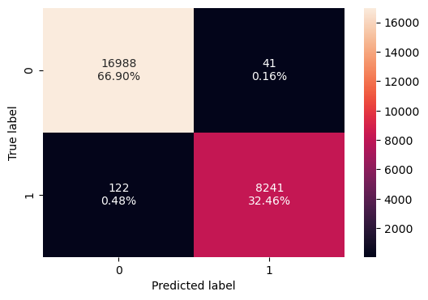

```python
confusion_matrix_sklearn(model, X_train, y_train)
```

```python
decision_tree_perf_train = model_performance_classification_sklearn(
    model, X_train, y_train
)
decision_tree_perf_train
```

|  | Accuracy | Recall | Precision | F1 |
| --- | --- | --- | --- | --- |
| 0 | 0.99358 | 0.98541 | 0.99505 | 0.99021 |

#### Checking model performance on test set

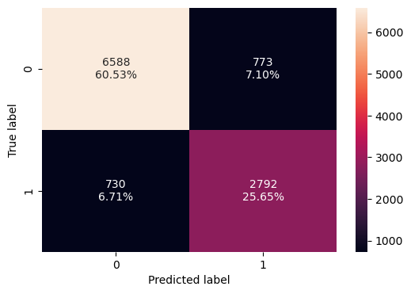

```python
confusion_matrix_sklearn(model, X_test, y_test)
```

```python
decision_tree_perf_test = model_performance_classification_sklearn(
    model, X_test, y_test
)
decision_tree_perf_test
```

|  | Accuracy | Recall | Precision | F1 |
| --- | --- | --- | --- | --- |
| 0 | 0.86189 | 0.79273 | 0.78317 | 0.78792 |

## Do we need to prune the tree?

Observations:

- Based on the performance metrics provided, here are some observations:
- Overfitting: The model seems to be overfitting the training data. This is evident by the significant performance drop from training to testing. The training accuracy is almost 99.36%, while the test accuracy is 86.19%. A similar drop is observed in other metrics as well.
- Recall, Precision, and F1 Score: On the training data, all of these metrics are extremely high, suggesting almost perfect classification. However, on the test set, these metrics drop considerably, indicating the model doesn't generalize well to unseen data.

Given the observations:

**Yes, pruning the decision tree would be a good idea. Pruning can help in reducing the complexity of the tree and making the model generalize better to unseen data, which can reduce overfitting.**

Additionally, pruning may lead to a slight decrease in training performance but is likely to improve test performance, making the model more robust and reliable for real-world predictions.

**Before pruning the tree let's check the important features.**

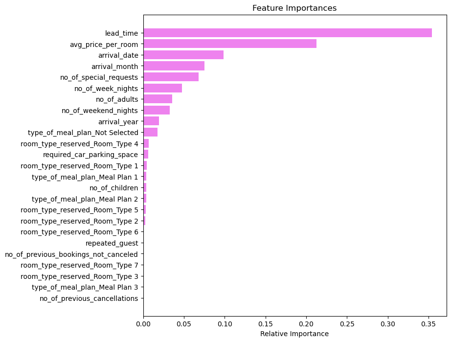

```python
feature_names = list(X_train.columns)
importances = model.feature_importances_
indices = np.argsort(importances)

plt.figure(figsize=(8, 8))
plt.title("Feature Importances")
plt.barh(range(len(indices)), importances[indices], color="violet", align="center")
plt.yticks(range(len(indices)), [feature_names[i] for i in indices])
plt.xlabel("Relative Importance")
plt.show()
```

**Pre-Pruning**

```python
# Choose the type of classifier.
estimator = DecisionTreeClassifier(random_state=1, class_weight="balanced")

# Grid of parameters to choose from
parameters = {
    "max_depth": np.arange(2, 7, 2),
    "max_leaf_nodes": [50, 75, 150, 250],
    "min_samples_split": [10, 30, 50, 70],
}

# Type of scoring used to compare parameter combinations
acc_scorer = make_scorer(f1_score)

# Run the grid search
grid_obj = GridSearchCV(estimator, parameters, scoring=acc_scorer, cv=5)
grid_obj = grid_obj.fit(X_train, y_train)

# Set the clf to the best combination of parameters
estimator = grid_obj.best_estimator_

# Fit the best algorithm to the data.
estimator.fit(X_train, y_train)
```

```
DecisionTreeClassifier(class_weight='balanced', max_depth=6, max_leaf_nodes=50,
                       min_samples_split=50, random_state=1)
```

#### Checking performance on training set

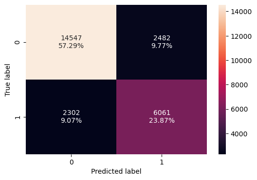

```python
confusion_matrix_sklearn(estimator, X_train, y_train)
```

```python
decision_tree_tune_perf_train = model_performance_classification_sklearn(
    estimator, X_train, y_train
)  ## Check performance on train set
print("Training Performance:")
print(decision_tree_tune_perf_train)
```

```
Training Performance:
   Accuracy  Recall  Precision      F1
0   0.81159 0.72474    0.70947 0.71702
```

#### Checking performance on test set

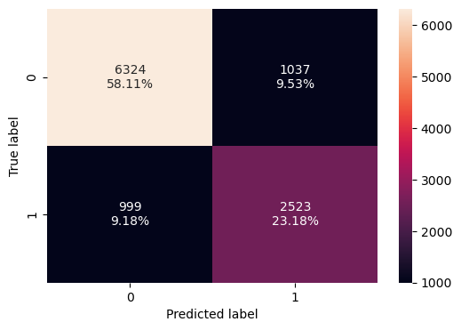

```python
confusion_matrix_sklearn(estimator, X_test, y_test)
```

```python
decision_tree_tune_perf_test = model_performance_classification_sklearn(
    estimator, X_test, y_test
)  ## Check performance on test set
print("Test Performance:")
print(decision_tree_tune_perf_test)
```

```
Test Performance:
   Accuracy  Recall  Precision      F1
0   0.81292 0.71635    0.70871 0.71251
```

**Insights:**

- Consistent Performance: The model has a similar performance on both training and test sets, indicating that it generalizes well and isn't overfitting or underfitting.
- Balanced Precision and Recall: Both precision and recall are above 70% for both training and test data. This suggests that the model is well-balanced in terms of not making too many false positives (as indicated by the relatively high precision) and not missing too many actual positives (as indicated by the relatively high recall).
- F1 Score: The F1 scores are relatively close for both training and test datasets, reaffirming the balance between precision and recall. This balanced performance can be particularly valuable if the costs associated with false negatives and false positives are roughly equivalent.

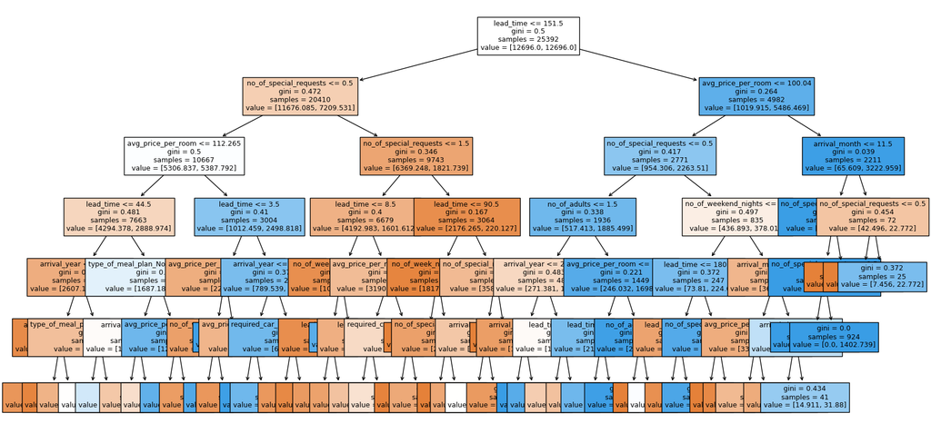

```python
plt.figure(figsize=(20, 10))
out = tree.plot_tree(
    estimator,
    feature_names=feature_names,
    filled=True,
    fontsize=9,
    node_ids=False,
    class_names=None,
)
# below code will add arrows to the decision tree split if they are missing
for o in out:
    arrow = o.arrow_patch
    if arrow is not None:
        arrow.set_edgecolor("black")
        arrow.set_linewidth(1)
plt.show()
```

```python
# Text report showing the rules of a decision tree -
print(tree.export_text(estimator, feature_names=feature_names, show_weights=True))
```

```
|--- lead_time <= 151.50
|   |--- no_of_special_requests <= 0.50
|   |   |--- avg_price_per_room <= 112.26
|   |   |   |--- lead_time <= 44.50
|   |   |   |   |--- arrival_year <= 2017.50
|   |   |   |   |   |--- arrival_month <= 9.50
|   |   |   |   |   |   |--- weights: [323.57, 54.65] class: 0
|   |   |   |   |   |--- arrival_month >  9.50
|   |   |   |   |   |   |--- weights: [567.36, 16.70] class: 0
|   |   |   |   |--- arrival_year >  2017.50
|   |   |   |   |   |--- type_of_meal_plan_Not Selected <= 0.50
|   |   |   |   |   |   |--- weights: [1430.71, 563.22] class: 0
|   |   |   |   |   |--- type_of_meal_plan_Not Selected >  0.50
|   |   |   |   |   |   |--- weights: [285.55, 282.37] class: 0
|   |   |   |--- lead_time >  44.50
|   |   |   |   |--- type_of_meal_plan_Not Selected <= 0.50
|   |   |   |   |   |--- arrival_month <= 8.50
|   |   |   |   |   |   |--- weights: [862.60, 1124.92] class: 1
|   |   |   |   |   |--- arrival_month >  8.50
|   |   |   |   |   |   |--- weights: [703.80, 394.71] class: 0
|   |   |   |   |--- type_of_meal_plan_Not Selected >  0.50
|   |   |   |   |   |--- avg_price_per_room <= 66.49
|   |   |   |   |   |   |--- weights: [35.04, 25.81] class: 0
|   |   |   |   |   |--- avg_price_per_room >  66.49
|   |   |   |   |   |   |--- weights: [85.74, 426.59] class: 1
|   |   |--- avg_price_per_room >  112.26
|   |   |   |--- lead_time <= 3.50
|   |   |   |   |--- avg_price_per_room <= 202.67
|   |   |   |   |   |--- no_of_week_nights <= 4.50
|   |   |   |   |   |   |--- weights: [221.43, 48.58] class: 0
|   |   |   |   |   |--- no_of_week_nights >  4.50
|   |   |   |   |   |   |--- weights: [0.75, 6.07] class: 1
|   |   |   |   |--- avg_price_per_room >  202.67
|   |   |   |   |   |--- weights: [0.75, 24.29] class: 1
|   |   |   |--- lead_time >  3.50
|   |   |   |   |--- arrival_year <= 2017.50
|   |   |   |   |   |--- avg_price_per_room <= 203.00
|   |   |   |   |   |   |--- weights: [120.78, 21.25] class: 0
|   |   |   |   |   |--- avg_price_per_room >  203.00
|   |   |   |   |   |   |--- weights: [0.75, 28.84] class: 1
```

[output cut: 90 more lines]

```
|   |   |   |   |   |   |--- weights: [14.91, 31.88] class: 1
|   |--- avg_price_per_room >  100.04
|   |   |--- arrival_month <= 11.50
|   |   |   |--- no_of_special_requests <= 2.50
|   |   |   |   |--- no_of_special_requests <= 0.50
|   |   |   |   |   |--- weights: [0.00, 1797.45] class: 1
|   |   |   |   |--- no_of_special_requests >  0.50
|   |   |   |   |   |--- weights: [0.00, 1402.74] class: 1
|   |   |   |--- no_of_special_requests >  2.50
|   |   |   |   |--- weights: [23.11, 0.00] class: 0
|   |   |--- arrival_month >  11.50
|   |   |   |--- no_of_special_requests <= 0.50
|   |   |   |   |--- weights: [35.04, 0.00] class: 0
|   |   |   |--- no_of_special_requests >  0.50
|   |   |   |   |--- weights: [7.46, 22.77] class: 1
```

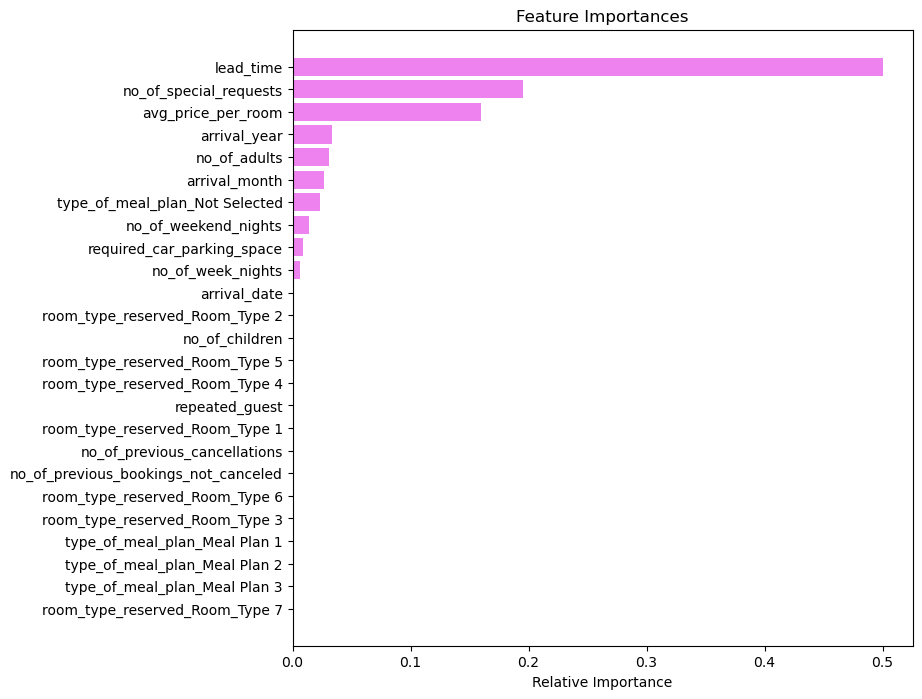

```python
# importance of features in the tree building

importances = estimator.feature_importances_
indices = np.argsort(importances)

plt.figure(figsize=(8, 8))
plt.title("Feature Importances")
plt.barh(range(len(indices)), importances[indices], color="violet", align="center")
plt.yticks(range(len(indices)), [feature_names[i] for i in indices])
plt.xlabel("Relative Importance")
plt.show()
```

**Cost Complexity Pruning**

```python
clf = DecisionTreeClassifier(random_state=1, class_weight="balanced")
path = clf.cost_complexity_pruning_path(X_train, y_train)
ccp_alphas, impurities = abs(path.ccp_alphas), path.impurities
```

```python
pd.DataFrame(path)
```

|  | ccp_alphas | impurities |
| --- | --- | --- |
| 0 | 0.00000 | 0.00908 |
| 1 | 0.00000 | 0.00908 |
| 2 | 0.00000 | 0.00908 |
| 3 | 0.00000 | 0.00908 |
| 4 | 0.00000 | 0.00908 |
| ... | ... | ... |
| 2068 | 0.00980 | 0.36112 |
| 2069 | 0.01099 | 0.37210 |
| 2070 | 0.01779 | 0.38990 |
| 2071 | 0.02893 | 0.41882 |
| 2072 | 0.08118 | 0.50000 |

2073 rows × 2 columns

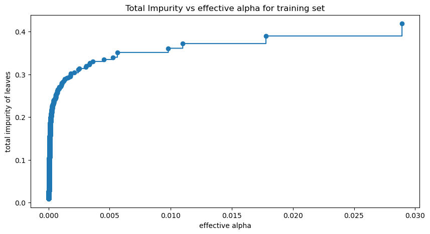

```python
fig, ax = plt.subplots(figsize=(10, 5))
ax.plot(ccp_alphas[:-1], impurities[:-1], marker="o", drawstyle="steps-post")
ax.set_xlabel("effective alpha")
ax.set_ylabel("total impurity of leaves")
ax.set_title("Total Impurity vs effective alpha for training set")
plt.show()
```

Next, we train a decision tree using effective alphas. The last value in `ccp_alphas` is the alpha value that prunes the whole tree, leaving the tree, `clfs[-1]`, with one node.

```python
clfs = []
for ccp_alpha in ccp_alphas:
    clf = DecisionTreeClassifier(
        random_state=1, ccp_alpha=ccp_alpha, class_weight="balanced"
    )
    clf.fit(X_train, y_train)  ## Fit decision tree on training data
    clfs.append(clf)
print(
    "Number of nodes in the last tree is: {} with ccp_alpha: {}".format(
        clfs[-1].tree_.node_count, ccp_alphas[-1]
    )
)
```

```
Number of nodes in the last tree is: 1 with ccp_alpha: 0.0811791438913716
```

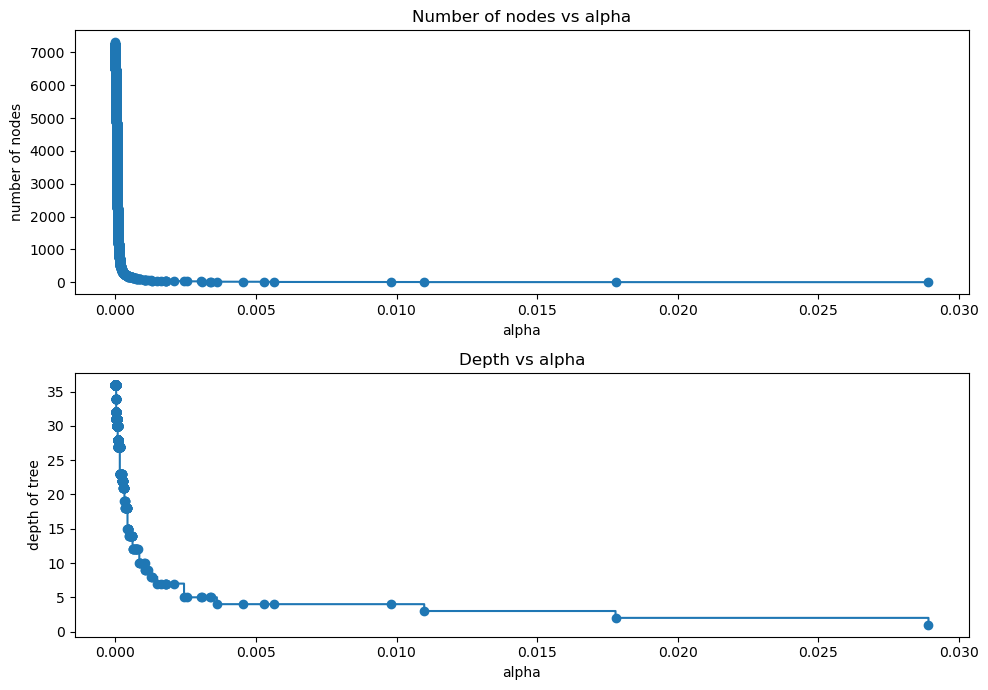

```python
clfs = clfs[:-1]
ccp_alphas = ccp_alphas[:-1]

node_counts = [clf.tree_.node_count for clf in clfs]
depth = [clf.tree_.max_depth for clf in clfs]
fig, ax = plt.subplots(2, 1, figsize=(10, 7))
ax[0].plot(ccp_alphas, node_counts, marker="o", drawstyle="steps-post")
ax[0].set_xlabel("alpha")
ax[0].set_ylabel("number of nodes")
ax[0].set_title("Number of nodes vs alpha")
ax[1].plot(ccp_alphas, depth, marker="o", drawstyle="steps-post")
ax[1].set_xlabel("alpha")
ax[1].set_ylabel("depth of tree")
ax[1].set_title("Depth vs alpha")
fig.tight_layout()
```

#### F1 Score vs alpha for training and testing sets

```python
f1_train = []
for clf in clfs:
    pred_train = clf.predict(X_train)
    values_train = f1_score(y_train, pred_train)
    f1_train.append(values_train)

f1_test = []
for clf in clfs:
    pred_test = clf.predict(X_test)
    values_test = f1_score(y_test, pred_test)
    f1_test.append(values_test)
```

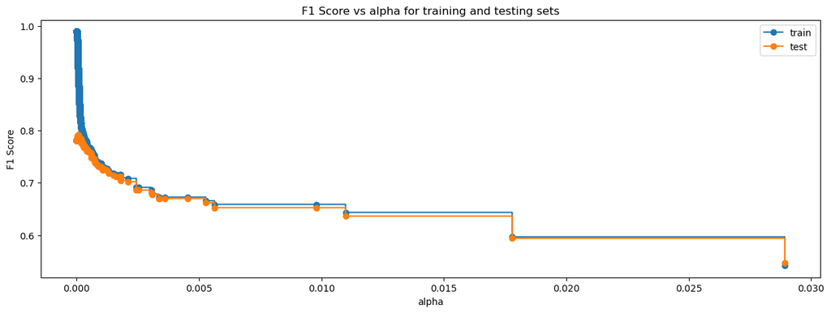

```python
fig, ax = plt.subplots(figsize=(15, 5))
ax.set_xlabel("alpha")
ax.set_ylabel("F1 Score")
ax.set_title("F1 Score vs alpha for training and testing sets")
ax.plot(ccp_alphas, f1_train, marker="o", label="train", drawstyle="steps-post")
ax.plot(ccp_alphas, f1_test, marker="o", label="test", drawstyle="steps-post")
ax.legend()
plt.show()
```

```python
index_best_model = np.argmax(f1_test)
best_model = clfs[index_best_model]
print(best_model)
```

```
DecisionTreeClassifier(ccp_alpha=7.309474235710808e-05, class_weight='balanced',
                       random_state=1)
```

#### Checking performance on training set

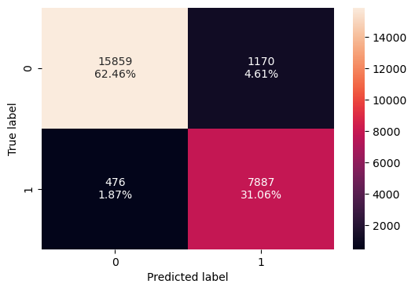

```python
confusion_matrix_sklearn(best_model, X_train, y_train)
```

```python
decision_tree_post_perf_train = model_performance_classification_sklearn(
    best_model, X_train, y_train
)
decision_tree_post_perf_train
```

|  | Accuracy | Recall | Precision | F1 |
| --- | --- | --- | --- | --- |
| 0 | 0.93518 | 0.94308 | 0.87082 | 0.90551 |

#### Checking performance on test set

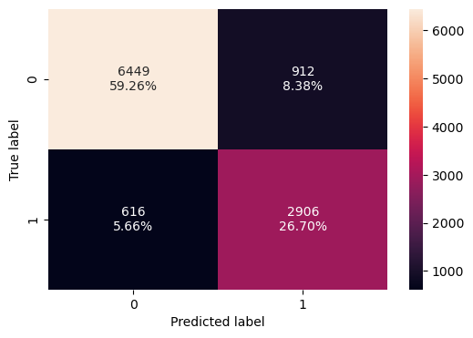

```python
confusion_matrix_sklearn(best_model, X_test, y_test)
```

```python
decision_tree_post_perf_test = model_performance_classification_sklearn(
    best_model, X_test, y_test
)
decision_tree_post_perf_test
```

|  | Accuracy | Recall | Precision | F1 |
| --- | --- | --- | --- | --- |
| 0 | 0.85960 | 0.82510 | 0.76113 | 0.79183 |

**Insights:**

- Overfitting: There's a noticeable difference between the training and testing metrics, especially in terms of accuracy and F1-score. The model has achieved around 93.5% accuracy on the training set but only about 86% on the testing set. This drop in performance indicates the model might be overfitting on the training data. Overfitting means the model has learned the training data too well, including its noise and outliers, which affects its generalization capability on new, unseen data.
- Recall vs. Precision: The recall in the test set is considerably higher than the precision. This suggests that the model is catching a large proportion of the positive cases but at the expense of incorrectly classifying some negative cases as positive.
- Balanced Performance: F1 score provides a balanced view of the model's performance, accounting for both false positives and false negatives. Although the F1 score for the training data is very high (around 90.5%), it drops to about 79.2% for the testing data, reinforcing the notion of possible overfitting.

**In summary, while the model has shown strong performance on the training data, there's room for improvement in its generalization to unseen data**

## Actionable Insights and Recommendations

- What profitable policies for cancellations and refunds can the hotel adopt?
- What other recommedations would you suggest to the hotel?

### Insights:

- Model Performance: The predictive capability of the model can provide the hotel with a proactive tool to anticipate cancellations. By understanding the patterns that lead to cancellations, the hotel can make better-informed decisions and adjust its operational and marketing strategies.
- Overfitting Concern: The model's sensitivity to training data suggests it may not generalize well to newer data or fluctuating market conditions. The hotel needs to be cautious while making decisions based solely on the model and should always account for external factors that could affect booking behaviors.
- Recall vs. Precision: A high recall indicates that the hotel is catching a majority of the cancellations. However, the disparity with precision means the model sometimes predicts cancellations when there aren't any. While the hotel can act proactively on these, it should be mindful not to alienate customers or create an impression of distrust.

### Recommendations:

**Cancellation Policies:**

- Flexible Booking Options: Offer a flexible booking option at a slightly higher price, allowing guests to cancel closer to the date. This way, guests willing to pay more for flexibility can do so, and the hotel can increase its revenue.
- Tiered Cancellation: Implement a tiered cancellation system where the fee increases as the check-in date approaches, with full charges for no-shows.

**Overbooking Strategy:**

- Threshold Management: Don't just overbook uniformly. Instead, set different overbooking thresholds based on seasonal demand, week vs. weekend, and other factors that affect booking patterns.
- Guest Management: In rare instances of overbooking, manage guest expectations by partnering with nearby hotels to accommodate them, offering transport, or providing discounts on future stays.

**Enhancing Model:**

**Promotions and Incentives:**

- Targeted Marketing: Identify guests with a high probability of canceling and send them personalized promotions or discounts on additional services like spa treatments, dining, or excursions.
- Loyalty Programs: Offer loyalty points or benefits for customers who maintain their bookings or rebook after a cancellation.

**Feedback Loop:**

- Post-Cancellation Survey: Implement a quick survey for guests who cancel to understand the reasons behind their decision. This information can provide invaluable insights for refining both the model and the hotel's offerings.
- Analyze Trends: Regularly analyze feedback to identify recurring reasons for cancellations and address them proactively.

**Re-evaluate Features:**

- Significance Analysis: Periodically analyze the significance of each feature in predicting cancellations. This can help in refining the model and shedding light on which areas the hotel needs to focus on.
- External Data Integration: Consider integrating external data like weather forecasts, flight cancellations, or local events, which might influence booking behaviors.

*In conclusion, by leveraging data and predictive modeling, the hotel can proactively adapt its strategies to minimize cancellations and maximize revenue. However, it's crucial to balance data-driven decisions with exceptional guest experiences to ensure long-term success and brand loyalty.*